# EWB_H4

Evan Woelk Balzer

20/02/2020

#1 I read it!

#2

When I was in elementary school, my mom bought me a book called ‘882 1/2 Facts About the Titanic’, so I’m really hoping I know enough about the ship and it’s historical context to get this right.

First, I suspect that the class to which a passenger belonged influenced their survival. Higher class citizens had numerous social advantages, and I predict that they were also shown preference when loading life boats. Another proxy for social status (and therefore survivorship) is the country of residence. I predict that American and British passengers had higher status than those from other countries, and as such were more likely to survive for the same reasons listed above. I also know the “women and children first” trope, and thus predict that gender influenced survivorship. I also expect that age will influence survivorship, and predict that because children were chosen to be placed on life rafts and the elderly would be less suited to surviving the cold, younger individuals will have higher survival. Finally, I know that individuals situated lower in the boat upon striking the iceberg were in many cases shut out by closing bulkheads and cascading water, and thus predict that cabin number reflects where individuals where spatially within the ship.

#3

```r
library(vcd)
library(popbio)
library(tidyverse)
#reading in the data as a tibble#
titanic <- read_csv("titanic.csv", col_names = TRUE, cols(pclass = col_factor(), survived = col_double(), Residence = col_factor(), name = col_character(), age = col_double(), sibsp = col_integer(), parch = col_integer(), ticket = col_character(), fare = col_double(), cabin = col_character(), embarked = col_character(), boat = col_character(), body = col_character(), home.dest = col_character(), Gender = col_factor()
))
```

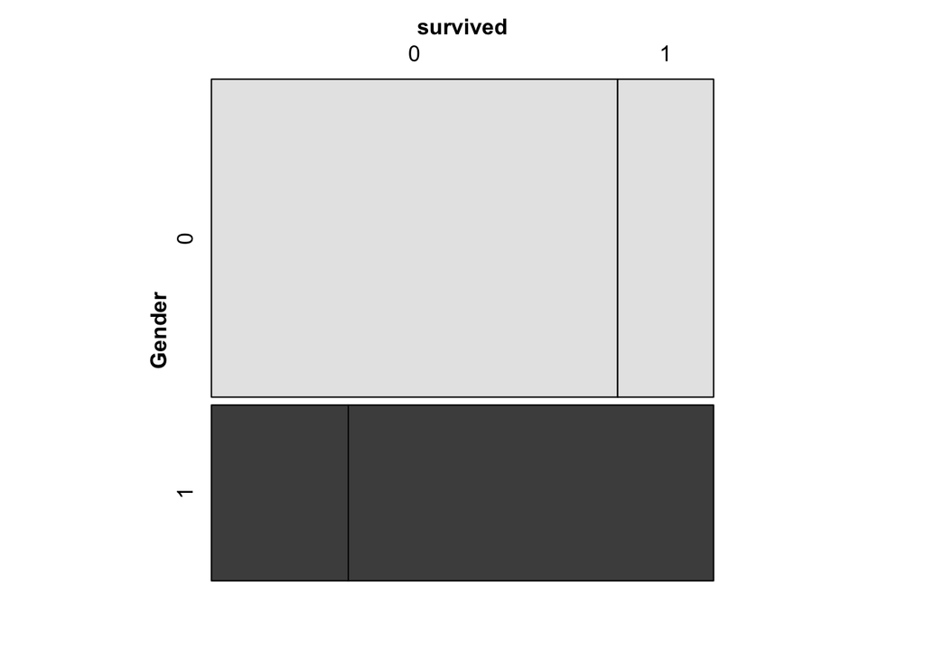

```r
#Plotting each against survivorship#
library(vcd)
mosaic(survived~Gender, data = titanic)
```

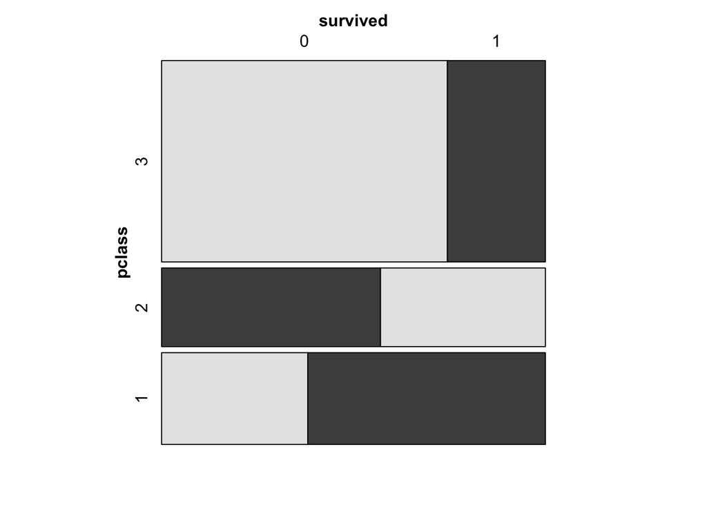

```r
mosaic(survived~pclass, data = titanic)
```

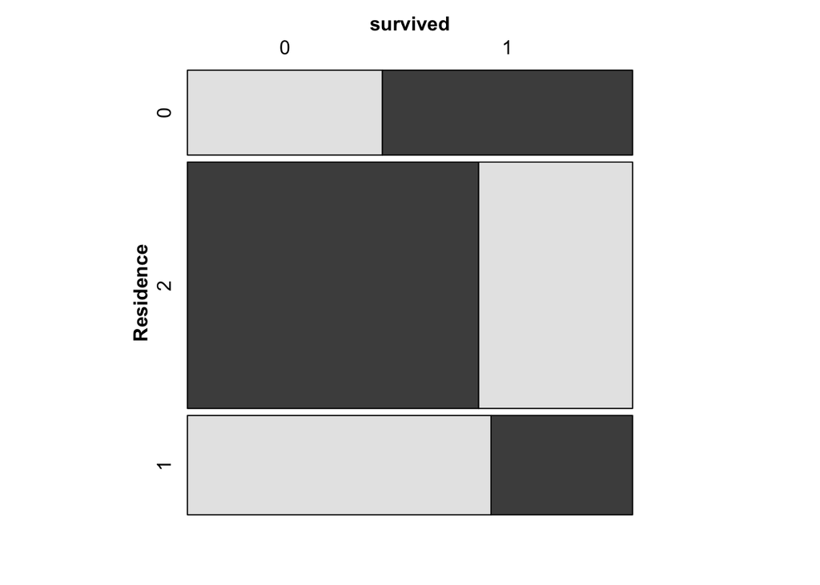

```r
mosaic(survived~Residence, data = titanic)
```

```r
library(popbio)
#getting just the age, fare and survivorship columns together without any nas#
vartitanic <- titanic %>% select(1, 3, 5, 9, 15, 2)
vartitanic
```

```
## # A tibble: 1,309 x 6
##    pclass Residence   age  fare Gender survived
##    <fct>  <fct>     <dbl> <dbl> <fct>     <dbl>
##  1 3      0            42  7.55 0             0
##  2 3      0            13 20.2  0             0
##  3 3      0            16 20.2  0             0
##  4 3      0            35 20.2  1             1
##  5 3      2            16  7.65 1             1
##  6 3      0            25  7.65 0             1
##  7 2      2            30 24    0             0
##  8 2      2            28 24    1             1
##  9 3      2            20  7.92 0             1
## 10 3      2            18  7.23 1             1
## # … with 1,299 more rows
```

```r
titanona<-drop_na(vartitanic)
titanona
```

```
## # A tibble: 1,045 x 6
##    pclass Residence   age  fare Gender survived
##    <fct>  <fct>     <dbl> <dbl> <fct>     <dbl>
##  1 3      0            42  7.55 0             0
##  2 3      0            13 20.2  0             0
##  3 3      0            16 20.2  0             0
##  4 3      0            35 20.2  1             1
##  5 3      2            16  7.65 1             1
##  6 3      0            25  7.65 0             1
##  7 2      2            30 24    0             0
##  8 2      2            28 24    1             1
##  9 3      2            20  7.92 0             1
## 10 3      2            18  7.23 1             1
## # … with 1,035 more rows
```

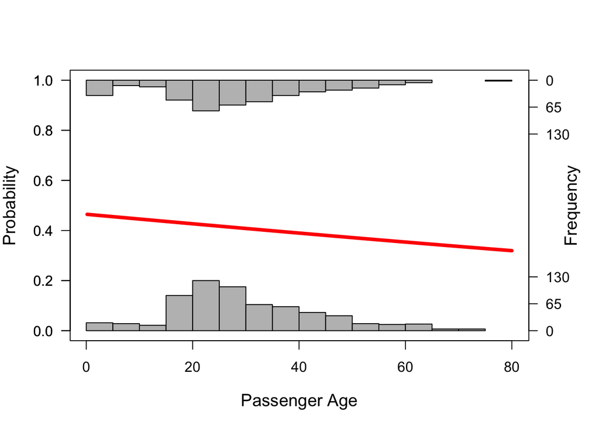

```r
#actually plotting the data#
logi.hist.plot(titanona$age, titanona$survived, boxp=FALSE,type="hist",col="gray", xlabel="Passenger Age")
```

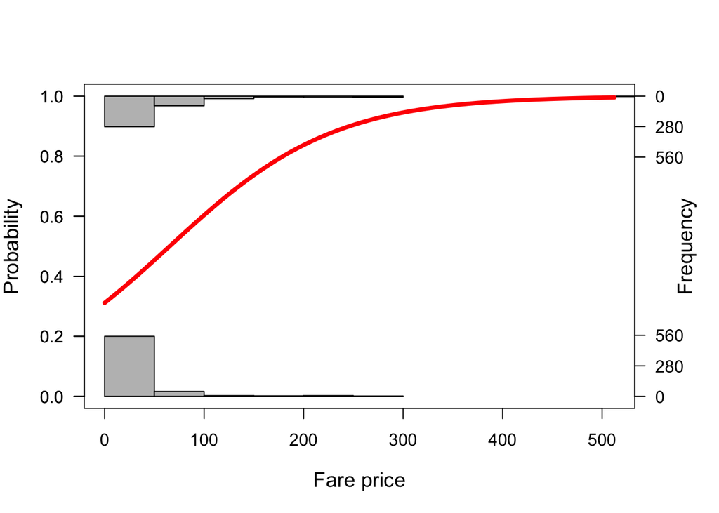

```r
logi.hist.plot(titanona$fare, titanona$survived, boxp=FALSE,type="hist",col="gray", xlabel="Fare price")
```

#Question 4

```r
library(bestglm)
titanona
```

```
## # A tibble: 1,045 x 6
##    pclass Residence   age  fare Gender survived
##    <fct>  <fct>     <dbl> <dbl> <fct>     <dbl>
##  1 3      0            42  7.55 0             0
##  2 3      0            13 20.2  0             0
##  3 3      0            16 20.2  0             0
##  4 3      0            35 20.2  1             1
##  5 3      2            16  7.65 1             1
##  6 3      0            25  7.65 0             1
##  7 2      2            30 24    0             0
##  8 2      2            28 24    1             1
##  9 3      2            20  7.92 0             1
## 10 3      2            18  7.23 1             1
## # … with 1,035 more rows
```

```r
#the bestglm function does not like tibbles apparently#
#time to convert it over!#
titanewna <- as.data.frame(titanona)
titanewna
```

```
##      pclass Residence     age     fare Gender survived
## 1         3         0 42.0000   7.5500      0        0
## 2         3         0 13.0000  20.2500      0        0
## 3         3         0 16.0000  20.2500      0        0
## 4         3         0 35.0000  20.2500      1        1
## 5         3         2 16.0000   7.6500      1        1
## 6         3         0 25.0000   7.6500      0        1
## 7         2         2 30.0000  24.0000      0        0
## 8         2         2 28.0000  24.0000      1        1
## 9         3         2 20.0000   7.9250      0        1
## 10        3         2 18.0000   7.2292      1        1
## 11        3         2 30.0000   7.2500      0        0
## 12        3         1 26.0000   8.0500      0        0
## 13        3         2 40.0000   9.4750      1        0
## 14        3         1  0.8333   9.3500      0        1
```

[output cut: 1031 more lines]

```r
bestglm(titanewna,IC="AIC",family=binomial)
```

```
## Morgan-Tatar search since family is non-gaussian.
```

```
## Note: factors present with more than 2 levels.
```

```
## AIC
## Best Model:
##               Df Sum Sq Mean Sq F value   Pr(>F)
## pclass         2  25.87   12.94   84.62  < 2e-16 ***
## Residence      2   1.33    0.66    4.34   0.0133 *
## age            1  10.64   10.64   69.63 2.26e-16 ***
## Gender         1  56.01   56.01  366.37  < 2e-16 ***
## Residuals   1038 158.68    0.15
## ---
## Signif. codes:  0 '***' 0.001 '**' 0.01 '*' 0.05 '.' 0.1 ' ' 1
```

#Question 5

```r
titamodel <- glm(survived~pclass+Residence+age+Gender, data = titanewna)
summary.lm(titamodel)
```

```
##
## Call:
## glm(formula = survived ~ pclass + Residence + age + Gender, data = titanewna)
##
## Residuals:
##      Min       1Q   Median       3Q      Max
## -1.06483 -0.24028 -0.08386  0.23171  0.99706
##
## Coefficients:
##               Estimate Std. Error t value Pr(>|t|)
## (Intercept)  0.3117211  0.0462477   6.740 2.62e-11 ***
## pclass2      0.1613618  0.0326901   4.936 9.28e-07 ***
## pclass1      0.3385403  0.0364875   9.278  < 2e-16 ***
## Residence2  -0.0646440  0.0357650  -1.807   0.0710 .
## Residence1  -0.0863200  0.0405522  -2.129   0.0335 *
## age         -0.0054253  0.0009384  -5.781 9.79e-09 ***
## Gender1      0.4900630  0.0256030  19.141  < 2e-16 ***
## ---
## Signif. codes:  0 '***' 0.001 '**' 0.01 '*' 0.05 '.' 0.1 ' ' 1
##
## Residual standard error: 0.391 on 1038 degrees of freedom
## Multiple R-squared:  0.3716, Adjusted R-squared:  0.368
## F-statistic: 102.3 on 6 and 1038 DF,  p-value: < 2.2e-16
```

#Question 6

```r
univariate.pclass <- glm(survived~pclass, data=titanewna, family=binomial(link="logit"))
summary(univariate.pclass)
```

```
##
## Call:
## glm(formula = survived ~ pclass, family = binomial(link = "logit"),
##     data = titanewna)
##
## Deviance Residuals:
##     Min       1Q   Median       3Q      Max
## -1.4243  -0.7795  -0.7795   0.9492   1.6367
##
## Coefficients:
##             Estimate Std. Error z value Pr(>|z|)
## (Intercept)  -1.0356     0.1017 -10.183  < 2e-16 ***
## pclass2       0.7969     0.1609   4.953 7.31e-07 ***
## pclass1       1.5994     0.1599  10.001  < 2e-16 ***
## ---
## Signif. codes:  0 '***' 0.001 '**' 0.01 '*' 0.05 '.' 0.1 ' ' 1
##
## (Dispersion parameter for binomial family taken to be 1)
##
##     Null deviance: 1413.6  on 1044  degrees of freedom
## Residual deviance: 1305.3  on 1042  degrees of freedom
## AIC: 1311.3
##
## Number of Fisher Scoring iterations: 4
```